# cardinal fitness — results summaries

## Statistical Methods

All analyses were performed in R (v4.5.2). Fecundity (egg counts) was modelled using a zero-inflated negative binomial mixed model fitted with glmmTMB, with cross direction and genetic line as fixed effects and replicate and plate well as nested random effects. Hatching rate was modelled using a binomial generalised linear mixed model (GLMM), also fitted with glmmTMB. Estimated marginal means and pairwise contrasts were obtained using emmeans. Post-blood-feeding survival, trans-heterozygote survival, and XA supplementation survival data were modelled using Weibull parametric survival models fitted with flexsurv. Midgut integrity (smurf assay) and adult eclosion data were modelled using binomial generalised linear models (GLMs) fitted with base R glm(). Gene expression data were analysed using the delta-delta-Ct method; ΔCt levels were modelled with a permutation-based linear model using emmeans for contrasts. Model tables were produced using sjPlot. Survival curves were visualised using Kaplan–Meier estimates alongside Weibull model predictions. All figures were produced using ggplot2 and patchwork.

## Fecundity

In the count component, both cd384R and cdg225 did not produce significantly different numbers of eggs (IRR = 1.09, 95%CI: 0.85-1.41, p = 0.49). For both lines where applicable the direction of cross was more important with the SDA x HET (1.31, [1.03-1.67], p = 0.029) and SDA x HOM (1.43, [1.09-1.88], p = 0.009) producing slightly more eggs than the inverse crosses.

> Note can make pairwise comparisons across all lines

|  | eggs |  |  |  |
| --- | --- | --- | --- | --- |
| Predictors | Incidence Rate Ratios | CI | p |  |
| Count Model |  |  |  |  |
| Intercept (QA383P, SDA×SDA) | 76.59 | 62.78 – 93.45 | **<0.001** |  |
| *cd*<sup>g225</sup> | 1.09 | 0.85 – 1.41 | 0.490 |  |
| *cd*<sup>g384</sup> | 1.48 | 1.18 – 1.85 | **0.001** |  |
| Female Het | 1.31 | 1.03 – 1.67 | **0.029** |  |
| Male Het | 1.12 | 0.86 – 1.46 | 0.416 |  |
| Female Hom | 1.43 | 1.09 – 1.88 | **0.009** |  |
| Male Hom | 0.74 | 0.53 – 1.04 | 0.084 |  |
| *cd*<sup>g225</sup> × Female Het | 1.00 | NaN – NaN | NaN |  |
| *cd*<sup>g384</sup> × Female Het | 0.63 | 0.47 – 0.86 | **0.004** |  |
| *cd*<sup>g225</sup> × Male Het | 0.90 | 0.62 – 1.31 | 0.569 |  |
| *cd*<sup>g384</sup> × Male Het | 0.80 | 0.59 – 1.10 | 0.177 |  |
| *cd*<sup>g384</sup> × Female Hom | 0.41 | 0.28 – 0.59 | **<0.001** |  |
| *cd*<sup>g384</sup> × Male Hom | 0.79 | 0.50 – 1.25 | 0.316 |  |
| Intercept (QA383P, SDA×SDA) | 9534217.44 | 196910.85 – 1587058406.93 |  |  |
| Zero-Inflated Model |  |  |  |  |
| Intercept (QA383P, SDA×SDA) | 0.47 | 0.39 – 0.56 | **<0.001** |  |
| Random Effects |  |  |  |  |
| σ<sup>2</sup> |  |  |  |  |
| τ<sub>00</sub> <sub>plate_well:rep</sub> | 0.05 |  |  |  |
| τ<sub>00</sub> <sub>rep</sub> | 0.00 |  |  |  |
| N <sub>plate_well</sub> | 506 |  |  |  |
| N <sub>rep</sub> | 10 |  |  |  |
| Observations | 546 |  |  |  |

```
# A tibble: 15 × 8
   line   cross          count     SE    df asymp.LCL asymp.UCL expected_count
   <fct>  <fct>          <dbl>  <dbl> <dbl>     <dbl>     <dbl>          <dbl>
 1 QA383P "WT"            76.6   7.77   Inf      62.8      93.4           52.2
 2 2360B5 "WT"            83.7   6.70   Inf      71.6      97.9           57.0
 3 1759   "WT"           113.    6.03   Inf     102.      126.            77.3
 4 QA383P "Female \nHET" 100.    7.30   Inf      87.1     116.            68.4
 5 2360B5 "Female \nHET" 110.  NaN      Inf     NaN       NaN             74.8
 6 1759   "Female \nHET"  94.4   7.91   Inf      80.1     111.            64.3
 7 QA383P "Male \nHET"    85.5   7.76   Inf      71.6     102.            58.3
 8 2360B5 "Male \nHET"    83.8   9.22   Inf      67.5     104.            57.1
 9 1759   "Male \nHET"   102.    7.32   Inf      88.4     117.            69.4
10 QA383P "Female \nHOM" 110.   10.5    Inf      91.1     132.            74.8
11 2360B5 "Female \nHOM"  NA    NA       NA      NA        NA             NA
12 1759   "Female \nHOM"  66.5   7.59   Inf      53.2      83.2           45.3
13 QA383P "Male \nHOM"    56.9   7.89   Inf      43.4      74.7           38.8
14 2360B5 "Male \nHOM"    NA    NA       NA      NA        NA             NA
15 1759   "Male \nHOM"    66.7   9.92   Inf      49.9      89.3           45.5
```

```
$line_by_cross
# A tibble: 9 × 10
  contrast cross estimate     SE    df z.ratio p.value ratio ratio.LCL ratio.UCL
  <fct>    <fct>    <dbl>  <dbl> <dbl>   <dbl>   <dbl> <dbl>     <dbl>     <dbl>
1 QA383P … "WT"   -0.0889 0.129    Inf  -0.690 7.69e-1 0.915     0.711     1.18
2 QA383P … "WT"   -0.393  0.114    Inf  -3.45  1.61e-3 0.675     0.540     0.844
3 2360B5 … "WT"   -0.304  0.0952   Inf  -3.19  4.06e-3 0.738     0.612     0.889
4 QA383P … "Fem…   0.0624 0.109    Inf   0.571 5.68e-1 1.06      0.859     1.32
5 QA383P … "Mal…   0.0202 0.142    Inf   0.142 9.89e-1 1.02      0.772     1.35
6 QA383P … "Mal…  -0.174  0.115    Inf  -1.52  2.83e-1 0.840     0.670     1.05
7 2360B5 … "Mal…  -0.195  0.131    Inf  -1.49  2.97e-1 0.823     0.637     1.06
8 QA383P … "Fem…   0.502  0.148    Inf   3.40  6.78e-4 1.65      1.24      2.21
9 QA383P … "Mal…  -0.159  0.203    Inf  -0.784 4.33e-1 0.853     0.573     1.27

$cross_by_line
# A tibble: 21 × 10
   contrast line  estimate    SE    df z.ratio p.value ratio ratio.LCL ratio.UCL
   <fct>    <fct>    <dbl> <dbl> <dbl>   <dbl>   <dbl> <dbl>     <dbl>     <dbl>
 1 "WT - F… QA38…  -0.271  0.124   Inf  -2.19  1.84e-1 0.762     0.598     0.972
 2 "WT - M… QA38…  -0.110  0.136   Inf  -0.813 9.27e-1 0.896     0.687     1.17
 3 "WT - F… QA38…  -0.361  0.139   Inf  -2.60  6.98e-2 0.697     0.531     0.915
 4 "WT - M… QA38…   0.297  0.172   Inf   1.73  4.15e-1 1.35      0.961     1.88
 5 "Female… QA38…   0.161  0.115   Inf   1.40  6.30e-1 1.17      0.937     1.47
 6 "Female… QA38…  -0.0894 0.118   Inf  -0.755 9.43e-1 0.914     0.725     1.15
 7 "Female… QA38…   0.568  0.156   Inf   3.63  2.60e-3 1.77      1.30      2.40
 8 "Male \… QA38…  -0.250  0.131   Inf  -1.91  3.10e-1 0.778     0.602     1.01
 9 "Male \… QA38…   0.407  0.166   Inf   2.46  1.00e-1 1.50      1.09      2.08
10 "Female… QA38…   0.658  0.168   Inf   3.91  8.79e-4 1.93      1.39      2.68
# ℹ 11 more rows
```

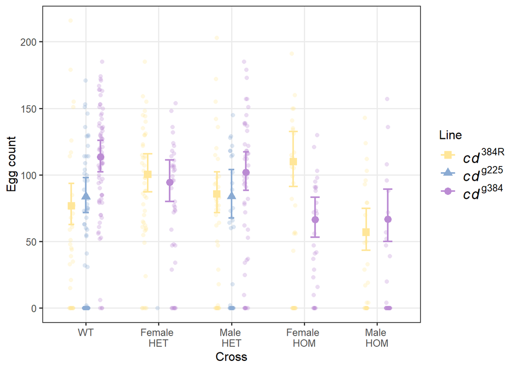